# Music Lyric Analysis

Frank Bonifazi

6/20/2019

```r
library('tidyverse')
library(tidytext)
library(tidyr)
```

# TITLE: Music by the Numbers!

A data science analysis by Francesco Bonifazi.

This project proposes and seeks to show that song lyrics can be a determing factor of the genre. We do not discount the power of harmony, melody, and rhythm to differentiate genre, but, it’s not common for musicians, educators and the like to classify music by the lyrics to songs.

# GOAL: The goal of this project is to use data science to analyze a library of Popular song lyrics, build/train a model to classify the words that best characterize the song’s genre. Ultimately, I plan to be able to use song lyrics not in the sample DB to test the model. Including ones from major artists and beyond.

#### Action Plan:

I will use the readily available subset of lyrics from The Million Song library. My sample size will be 57,000 songs of multiple genres and artists. From this, I will cut it into training and test data starting at .75 training.

To train the prediction, I will need the most likely genre for each song. Unfortunately, this is not provided with the freely available data. Due to the huge task to select the genre for each of the 57,000 songs, I will focus on the artist for each group of songs using multiple sources wher they categorize music. I will also list a “sub-genre” in-case this is more effective to use.

# Business Case:

WHy would anyone or any company care whether lyrics define the song’s genre?

Let’s look at potential company use. Businesses such at Pandora and Spotify have been analyzing and classifying music (including songs with lyrics) for their customers to provide a “premium” listening experience. Seems that the common thought is that most listeners don’t have a wide range of music they enjoy, so keeping them on the service relies in part to providing recommendations, and even “next-up” of songs. While these algorhythms are valuable corporate secrets, to my knowledge none have focused on lyrics exclusively. It would benefit these music service providers to complement their own AI/ML solutions with another one focused on lyrics. This would offer both comfirmation of music analysis as well as new insights.

Next, let’s look at songwriters, their management, and licensing companies such as ASCAP and BMI.

For songwriters, there is a sub-group that are only lyricists, meaning someone else composes the music. Composers look for lyrics to compose to. Lyricists look for composers who are known for specific genres. Many, haven’t worked together before. Managers often have knowledge of both sides, and will broaker deals that combine their talents. Giving songwriters and composers the ability look for each other by matching lyrics with music could be a further democratization of the music industry.

Licensing companies deal with both lyrics and songs as legal assets they manage for artists. While this is not the main part of their business, they would benefit from validating the lyric’s genre compared to what the artist thinks it is.

When another artist wants to record someone else’s song, they had to pay license fees to ASCAP for example. ASCAP has a website that deals with this from a financial aspect, but not from a search and select song aspect. Having this capability would enhance their service offering to their clients, be a competitive differentiator, and potentially increase profits through “premium” services.

```r
songdata <- read_csv("songdata.csv")
```

There are 4 columns in this dataset

```r
class(songdata)
```

```
## [1] "spec_tbl_df" "tbl_df"      "tbl"         "data.frame"
```

Looks like a data frame

Try converting to a tibble

```r
songdata_tibble <- as_tibble(songdata)
class(songdata_tibble)
```

```
## [1] "tbl_df"     "tbl"        "data.frame"
```

Looks the same… but, might be different internally?

Count the rows

```r
songdata_tibble %>%
count()
```

```
## # A tibble: 1 x 1
##       n
##   <int>
## 1 57650
```

There are 57,650 rows of data in this dataset

```r
songdata_tibble %>%
  select(artist) %>%
  unique()
```

```
## # A tibble: 643 x 1
##    artist
##    <chr>
##  1 ABBA
##  2 Ace Of Base
##  3 Adam Sandler
##  4 Adele
##  5 Aerosmith
##  6 Air Supply
##  7 Aiza Seguerra
##  8 Alabama
##  9 Alan Parsons Project
## 10 Aled Jones
## # … with 633 more rows
```

There are 643 artists in this dataset

```r
head (songdata_tibble)
```

```
## # A tibble: 6 x 4
##   artist song         link                 text
##   <chr>  <chr>        <chr>                <chr>
## 1 ABBA   Ahe's My Ki… /a/abba/ahes+my+kin… "Look at her face, it's a wonde…
## 2 ABBA   Andante, An… /a/abba/andante+and… "Take it easy with me, please  …
## 3 ABBA   As Good As … /a/abba/as+good+as+… "I'll never know why I had to g…
## 4 ABBA   Bang         /a/abba/bang_205984… "Making somebody happy is a que…
## 5 ABBA   Bang-A-Boom… /a/abba/bang+a+boom… "Making somebody happy is a que…
## 6 ABBA   Burning My … /a/abba/burning+my+… "Well, you hoot and you holler …
```

How many ABBA song?

```r
songdata_tibble %>%
  filter (artist == "ABBA") %>%
count()
```

```
## # A tibble: 1 x 1
##       n
##   <int>
## 1   113
```

```r
songdata_tibble %>%
  filter (artist == "ABBA") %>%
unnest_tokens(word, text)
```

```
## # A tibble: 28,724 x 4
##    artist song                link                                 word
##    <chr>  <chr>               <chr>                                <chr>
##  1 ABBA   Ahe's My Kind Of G… /a/abba/ahes+my+kind+of+girl_205984… look
##  2 ABBA   Ahe's My Kind Of G… /a/abba/ahes+my+kind+of+girl_205984… at
##  3 ABBA   Ahe's My Kind Of G… /a/abba/ahes+my+kind+of+girl_205984… her
##  4 ABBA   Ahe's My Kind Of G… /a/abba/ahes+my+kind+of+girl_205984… face
##  5 ABBA   Ahe's My Kind Of G… /a/abba/ahes+my+kind+of+girl_205984… it's
##  6 ABBA   Ahe's My Kind Of G… /a/abba/ahes+my+kind+of+girl_205984… a
##  7 ABBA   Ahe's My Kind Of G… /a/abba/ahes+my+kind+of+girl_205984… wonderf…
##  8 ABBA   Ahe's My Kind Of G… /a/abba/ahes+my+kind+of+girl_205984… face
##  9 ABBA   Ahe's My Kind Of G… /a/abba/ahes+my+kind+of+girl_205984… and
## 10 ABBA   Ahe's My Kind Of G… /a/abba/ahes+my+kind+of+girl_205984… it
## # … with 28,714 more rows
```

Search for no. times “girl” is used Use tidy text’s unnest function to arrange one word per row.

```r
songdata_tibble %>%
  filter (artist == "ABBA") %>%
  group_by(song) %>%
unnest_tokens(word, text) %>%
filter(word == "girl") %>%
  count()
```

```
## # A tibble: 2 x 2
## # Groups:   song [2]
##   song                  n
##   <chr>             <int>
## 1 I Have A Dream        1
## 2 Man In The Middle     1
```

2 ABBA songs have the word “girl” in them…??? Seems low.

Out of 113 ABBA songs… but, it misssed their 1st song “Ahe’s My Kind Of Girl” which I checked has “girl” 4 times.

I have a lot to learn about text parsing…

Let’s get ride of word such as “the”, “a” etc. Called “stop_words” It seemed to choke on all rows….doing it for ABBA to see results.

```r
songdata_tibble %>%
  filter (artist == "ABBA") %>%
  unnest_tokens(word, text) %>%
  anti_join(stop_words) %>%
  count(word, sort = TRUE)
```

```
## # A tibble: 1,917 x 2
##    word      n
##    <chr> <int>
##  1 la      376
##  2 love    187
##  3 gonna    86
##  4 time     81
##  5 feel     80
##  6 life     79
##  7 baby     69
##  8 day      68
##  9 girl     68
## 10 ah       67
## # … with 1,907 more rows
```

```r
library(ggplot2)
```

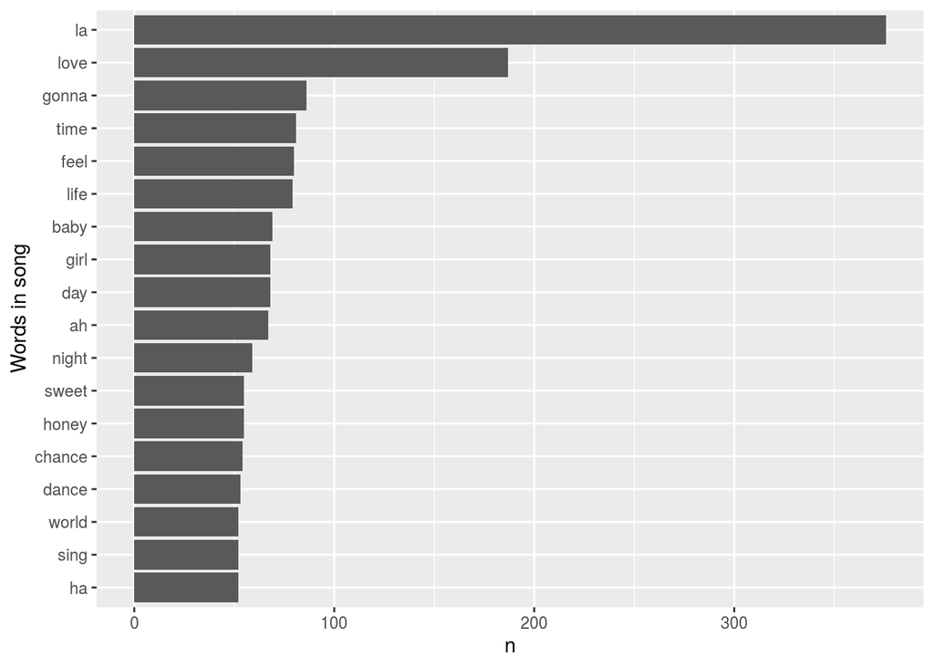

```r
songdata_tibble %>%
  filter (artist == "ABBA") %>%
  unnest_tokens(word, text) %>%
  anti_join(stop_words) %>%
  count(word, sort = TRUE) %>%

  mutate(word = reorder(word,n))  %>%
  filter(n > 50) %>%

  ggplot(aes(word, n)) +
    geom_col() +
  xlab("Words in song") +
coord_flip()
```

#FB: This shows ’girl" is used by ABBA over 50 times!

#FB: I want to use a randon selection since this is an alhpabetical list.

```r
dat=songdata_tibble
set.seed(123)
training_split = 0.012 #1% data for train, .25% for test
smp_size = floor(training_split * nrow(dat))
train_ind = sample(seq_len(nrow(dat)), size = smp_size)

#test_ind = dat -train_ind]

train_dat = dat[train_ind,]
test_dat = dat[-train_ind,]

#train_dat
test_dat
```

```
## # A tibble: 56,959 x 4
##    artist song         link                 text
##    <chr>  <chr>        <chr>                <chr>
##  1 ABBA   Ahe's My Ki… /a/abba/ahes+my+kin… "Look at her face, it's a wond…
##  2 ABBA   Andante, An… /a/abba/andante+and… "Take it easy with me, please …
##  3 ABBA   As Good As … /a/abba/as+good+as+… "I'll never know why I had to …
##  4 ABBA   Bang         /a/abba/bang_205984… "Making somebody happy is a qu…
##  5 ABBA   Bang-A-Boom… /a/abba/bang+a+boom… "Making somebody happy is a qu…
##  6 ABBA   Burning My … /a/abba/burning+my+… "Well, you hoot and you holler…
##  7 ABBA   Cassandra    /a/abba/cassandra_2… "Down in the street they're al…
##  8 ABBA   Chiquitita   /a/abba/chiquitita_… "Chiquitita, tell me what's wr…
##  9 ABBA   Crazy World  /a/abba/crazy+world… "I was out with the morning su…
## 10 ABBA   Crying Over… /a/abba/crying+over… "I'm waitin' for you baby  \nI…
## # … with 56,949 more rows
```

```r
# "Tidy:
set.seed(123)
training_split = 0.75 #1% data for train, .25% for test
train_dat = dat %>% sample_frac(training_split)
test_dat = dat %>% anti_join(train_dat, by = 'song')
#train_dat
test_dat
```

```
## # A tibble: 10,166 x 4
##    artist song             link                   text
##    <chr>  <chr>            <chr>                  <chr>
##  1 ABBA   Ahe's My Kind O… /a/abba/ahes+my+kind+… "Look at her face, it's …
##  2 ABBA   Disillusion      /a/abba/disillusion_2… "Changing, moving in a c…
##  3 ABBA   Does Your Mothe… /a/abba/does+your+mot… "You're so hot, teasing …
##  4 ABBA   Fernando (In Sp… /a/abba/fernando+in+s… "Puedes escuchar Fernand…
##  5 ABBA   From A Twinklin… /a/abba/from+a+twinkl… "Twinkle, Twinkle little…
##  6 ABBA   Gimme Gimme Gim… /a/abba/gimme+gimme+g… "Half past twelve  \nAnd…
##  7 ABBA   Givin' A Little… /a/abba/givin+a+littl… "There's a gentleness to…
##  8 ABBA   Happy Hawaii     /a/abba/happy+hawaii_… "Agnetha, Frida Early th…
##  9 ABBA   He Is Your Brot… /a/abba/he+is+your+br… "Benny I was a fighter, …
## 10 ABBA   I Am Just A Girl /a/abba/i+am+just+a+g… "I am just a girl  \nOne…
## # … with 10,156 more rows
```

```r
# Clean up data to remove ID
train_dat = train_dat %>% select(-link)
test_dat = test_dat %>% select(-link)
test_dat
```

```
## # A tibble: 10,166 x 3
##    artist song                     text
##    <chr>  <chr>                    <chr>
##  1 ABBA   Ahe's My Kind Of Girl    "Look at her face, it's a wonderful fac…
##  2 ABBA   Disillusion              "Changing, moving in a circle  \nI can …
##  3 ABBA   Does Your Mother Know    "You're so hot, teasing me  \nSo you're…
##  4 ABBA   Fernando (In Spanish)    "Puedes escuchar Fernando?  \nMe recuer…
##  5 ABBA   From A Twinkling Star T… "Twinkle, Twinkle little star  \nHow I …
##  6 ABBA   Gimme Gimme Gimme        "Half past twelve  \nAnd I'm watching t…
##  7 ABBA   Givin' A Little Bit More "There's a gentleness to everything you…
##  8 ABBA   Happy Hawaii             "Agnetha, Frida Early this morning I dr…
##  9 ABBA   He Is Your Brother       "Benny I was a fighter, always looking …
## 10 ABBA   I Am Just A Girl         "I am just a girl  \nOne among the othe…
## # … with 10,156 more rows
```